# Binary Classification Analysis

- Show All Code
- Hide All Code
- View Source

Descriptive and Exploratory Study

Author

Raed Mohamed Amine Hamrouni

Published

January 15, 2026

```python
# Load libraries
import pandas as pd
import numpy as np
import matplotlib.pyplot as plt
import seaborn as sns
from sklearn.model_selection import train_test_split, cross_val_score
from sklearn.preprocessing import StandardScaler
from sklearn.impute import SimpleImputer
from sklearn.linear_model import LogisticRegression
from sklearn.ensemble import RandomForestClassifier, GradientBoostingClassifier
from sklearn.metrics import (
    f1_score, classification_report, confusion_matrix,
    accuracy_score, precision_score, recall_score, roc_auc_score, roc_curve
)
import warnings
warnings.filterwarnings('ignore')

# Set plotting style
sns.set_style('whitegrid')
plt.rcParams['figure.figsize'] = (10, 6)

# Load the dataset
data = pd.read_csv('data.csv')

print(f"Data loaded: {data.shape[0]} observations")
```

```
Data loaded: 260 observations
```

# 1 Introduction

## 1.1 Study Context

This document presents a comprehensive analysis of a dataset for binary classification. The goal is to predict class labels (0 or 1) using machine learning techniques. This analysis aims to provide an in-depth understanding of the data characteristics, model performance, and operational modalities.

## 1.2 Analysis Objectives

The main objectives of this study are:

- **Describe the population**: characterize samples by features and class distribution
- **Analyze model performance**: identify the best performing classifiers
- **Examine evaluation metrics**: understand F1 score and supporting metrics
- **Explore feature importance**: observe which variables drive predictions
- **Identify associated factors**: highlight relationships between different variables

## 1.3 Methodology

The analysis relies on descriptive and exploratory statistical methods using Python and the following packages:

- `pandas` for data manipulation
- `numpy` for numerical operations
- `scikit-learn` for machine learning models and metrics
- `matplotlib` and `seaborn` for visualizations

# 2 Data Inspection

## 2.1 Column Names

```python
print(data.columns.tolist())
```

```
['ID', 'Gender', 'Nationality', 'Major', 'Level', 'IE1', 'SMSK3', 'RAS1', 'RAS2', 'SMSK1', 'SMSK4', 'IE2', 'TL1', 'RAS3', 'IE3', 'RAS4', 'RAS5', 'IE4', 'SMSK2', 'TL2', 'TL3', 'PSD1', 'PSD2', 'PSD3', 'IE5', 'PSD4', 'PSD5', 'IM1', 'IM2', 'IM3', 'IM4', 'IM5', 'IM6', 'W1', 'W2', 'W3', 'Employed', 'Score…
```

The dataset contains several key variables allowing a multidimensional analysis of the classification task.

## 2.2 First Observations

```python
data.head()
```

|  | ID | Gender | Nationality | Major | Level | IE1 | SMSK3 | RAS1 | RAS2 | SMSK1 | ... | IM3 | IM4 | IM5 | IM6 | W1 | W2 | W3 | Employed | Score | Class |
| --- | --- | --- | --- | --- | --- | --- | --- | --- | --- | --- | --- | --- | --- | --- | --- | --- | --- | --- | --- | --- | --- |
| 0 | 1 | 0 | 1 | 0 | 2 | 4 | 3 | 4 | 4 | 2 | ... | 4 | 4 | 4 | 4 | 4.0 | 4.0 | 4.0 | 1.0 | 3.20 | 1 |
| 1 | 2 | 0 | 0 | 0 | 2 | 4 | 4 | 4 | 4 | 3 | ... | 4 | 3 | 4 | 4 | 3.0 | 4.0 | 3.0 | 0.0 | 3.82 | 1 |
| 2 | 3 | 0 | 1 | 0 | 1 | 3 | 2 | 3 | 4 | 3 | ... | 3 | 4 | 4 | 3 | 4.0 | 4.0 | 2.0 | 1.0 | 3.75 | 1 |
| 3 | 4 | 1 | 1 | 1 | 3 | 4 | 4 | 4 | 4 | 4 | ... | 4 | 4 | 4 | 4 | 3.0 | 4.0 | 4.0 | 1.0 | 3.70 | 1 |
| 4 | 5 | 0 | 0 | 0 | 2 | 4 | 3 | 3 | 4 | 3 | ... | 4 | 3 | 3 | 3 | 4.0 | 4.0 | 2.0 | 1.0 | 3.82 | 0 |

5 rows × 39 columns

## 2.3 Data Structure

```python
data.info()
```

```
<class 'pandas.core.frame.DataFrame'>
RangeIndex: 260 entries, 0 to 259
Data columns (total 39 columns):
 #   Column       Non-Null Count  Dtype
---  ------       --------------  -----
 0   ID           260 non-null    int64
 1   Gender       260 non-null    int64
 2   Nationality  260 non-null    int64
 3   Major        260 non-null    int64
 4   Level        260 non-null    int64
 5   IE1          260 non-null    int64
 6   SMSK3        260 non-null    int64
 7   RAS1         260 non-null    int64
 8   RAS2         260 non-null    int64
 9   SMSK1        260 non-null    int64
```

[output cut: 31 more lines]

**Interpretation**: The dataset is structured with numerical variables (features) and a categorical target (Class), which allows both quantitative and qualitative analysis.

# 3 Descriptive Analysis

## 3.1 Class Characteristics

### 3.1.1 Summary Statistics

```python
class_summary = data['Class'].value_counts().to_frame()
class_summary['Percentage'] = (class_summary['count'] / len(data) * 100).round(1)
class_summary
```

| Class | count | Percentage |
| --- | --- | --- |
| 0 | 133 | 51.2 |
| 1 | 127 | 48.8 |

### 3.1.2 Class Distribution

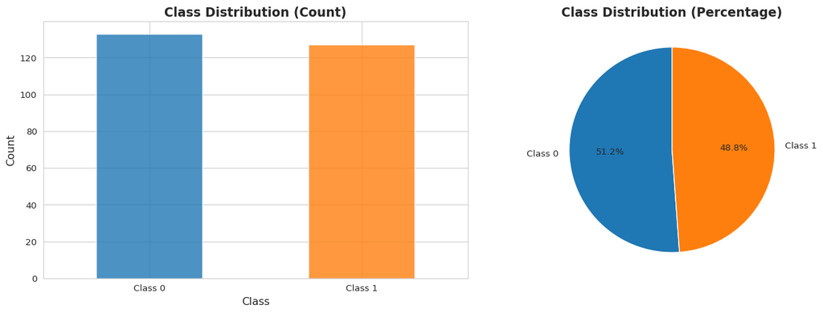

```python
fig, axes = plt.subplots(1, 2, figsize=(14, 5))

# Count plot
data['Class'].value_counts().plot(kind='bar', ax=axes[0], color=['#1f77b4', '#ff7f0e'], alpha=0.8)
axes[0].set_title('Class Distribution (Count)', fontsize=14, fontweight='bold')
axes[0].set_xlabel('Class', fontsize=12)
axes[0].set_ylabel('Count', fontsize=12)
axes[0].set_xticklabels(['Class 0', 'Class 1'], rotation=0)

# Pie chart
class_counts = data['Class'].value_counts()
axes[1].pie(class_counts, labels=['Class 0', 'Class 1'], autopct='%1.1f%%',
            startangle=90, colors=['#1f77b4', '#ff7f0e'])
axes[1].set_title('Class Distribution (Percentage)', fontsize=14, fontweight='bold')

plt.tight_layout()
plt.show()
```

**Key Observations**:

- The distribution shows a relatively balanced class split
- Both classes are well represented, making standard metrics reliable
- No special sampling techniques required for handling class imbalance

## 3.2 Feature Statistics

```python
# Numerical features summary
numeric_features = data.select_dtypes(include=[np.number]).columns.tolist()
if 'ID' in numeric_features:
    numeric_features.remove('ID')
if 'Class' in numeric_features:
    numeric_features.remove('Class')

summary_stats = data[numeric_features].describe().T
summary_stats
```

|  | count | mean | std | min | 25% | 50% | 75% | max |
| --- | --- | --- | --- | --- | --- | --- | --- | --- |
| Gender | 260.0 | 0.400000 | 0.490843 | 0.0 | 0.00 | 0.00 | 1.00 | 1.0 |
| Nationality | 260.0 | 0.303846 | 0.460804 | 0.0 | 0.00 | 0.00 | 1.00 | 1.0 |
| Major | 260.0 | 0.453846 | 0.498825 | 0.0 | 0.00 | 0.00 | 1.00 | 1.0 |
| Level | 260.0 | 1.973077 | 0.442926 | 1.0 | 2.00 | 2.00 | 2.00 | 3.0 |
| IE1 | 260.0 | 3.523077 | 0.592298 | 1.0 | 3.00 | 4.00 | 4.00 | 4.0 |
| SMSK3 | 260.0 | 3.226923 | 0.744637 | 1.0 | 3.00 | 3.00 | 4.00 | 4.0 |
| RAS1 | 260.0 | 3.476923 | 0.654245 | 1.0 | 3.00 | 4.00 | 4.00 | 4.0 |
| RAS2 | 260.0 | 3.542308 | 0.629195 | 1.0 | 3.00 | 4.00 | 4.00 | 4.0 |
| SMSK1 | 260.0 | 3.073077 | 0.851099 | 1.0 | 3.00 | 3.00 | 4.00 | 4.0 |
| SMSK4 | 260.0 | 3.215385 | 0.702831 | 1.0 | 3.00 | 3.00 | 4.00 | 4.0 |
| IE2 | 260.0 | 3.492308 | 0.599178 | 1.0 | 3.00 | 4.00 | 4.00 | 4.0 |
| TL1 | 260.0 | 3.446154 | 0.692615 | 1.0 | 3.00 | 4.00 | 4.00 | 4.0 |
| RAS3 | 260.0 | 3.457692 | 0.709926 | 1.0 | 3.00 | 4.00 | 4.00 | 4.0 |
| IE3 | 260.0 | 3.311538 | 0.724010 | 1.0 | 3.00 | 3.00 | 4.00 | 4.0 |
| RAS4 | 260.0 | 3.473077 | 0.688604 | 1.0 | 3.00 | 4.00 | 4.00 | 4.0 |
| RAS5 | 260.0 | 2.800000 | 0.882258 | 1.0 | 2.00 | 3.00 | 3.00 | 4.0 |
| IE4 | 260.0 | 3.315385 | 0.692314 | 1.0 | 3.00 | 3.00 | 4.00 | 4.0 |
| SMSK2 | 260.0 | 3.300000 | 0.710104 | 1.0 | 3.00 | 3.00 | 4.00 | 4.0 |
| TL2 | 260.0 | 3.253846 | 0.738479 | 1.0 | 3.00 | 3.00 | 4.00 | 4.0 |
| TL3 | 260.0 | 3.473077 | 0.682974 | 1.0 | 3.00 | 4.00 | 4.00 | 4.0 |
| PSD1 | 260.0 | 3.442308 | 0.675365 | 1.0 | 3.00 | 4.00 | 4.00 | 4.0 |
| PSD2 | 260.0 | 3.334615 | 0.627209 | 1.0 | 3.00 | 3.00 | 4.00 | 4.0 |
| PSD3 | 260.0 | 3.230769 | 0.761410 | 1.0 | 3.00 | 3.00 | 4.00 | 4.0 |
| IE5 | 260.0 | 3.161538 | 0.764096 | 1.0 | 3.00 | 3.00 | 4.00 | 4.0 |
| PSD4 | 260.0 | 3.226923 | 0.696410 | 1.0 | 3.00 | 3.00 | 4.00 | 4.0 |
| PSD5 | 260.0 | 3.173077 | 0.733141 | 1.0 | 3.00 | 3.00 | 4.00 | 4.0 |
| IM1 | 260.0 | 3.338462 | 0.838770 | 1.0 | 3.00 | 4.00 | 4.00 | 4.0 |
| IM2 | 260.0 | 3.392308 | 0.760980 | 1.0 | 3.00 | 4.00 | 4.00 | 4.0 |
| IM3 | 260.0 | 3.557692 | 0.652097 | 1.0 | 3.00 | 4.00 | 4.00 | 4.0 |
| IM4 | 260.0 | 3.426923 | 0.728916 | 1.0 | 3.00 | 4.00 | 4.00 | 4.0 |
| IM5 | 260.0 | 3.376923 | 0.768747 | 1.0 | 3.00 | 4.00 | 4.00 | 4.0 |
| IM6 | 260.0 | 3.265385 | 0.807036 | 1.0 | 3.00 | 3.00 | 4.00 | 4.0 |
| W1 | 241.0 | 3.344398 | 0.852484 | 1.0 | 3.00 | 4.00 | 4.00 | 4.0 |
| W2 | 246.0 | 3.394309 | 0.794758 | 1.0 | 3.00 | 4.00 | 4.00 | 4.0 |
| W3 | 210.0 | 2.566667 | 1.144085 | 1.0 | 1.00 | 3.00 | 4.00 | 4.0 |
| Employed | 258.0 | 0.848837 | 0.358904 | 0.0 | 1.00 | 1.00 | 1.00 | 1.0 |
| Score | 260.0 | 3.510577 | 0.452017 | 0.0 | 3.43 | 3.51 | 3.71 | 4.0 |

# 4 Data Preprocessing

## 4.1 Missing Value Analysis

```python
missing_values = data.isnull().sum()
missing_values[missing_values > 0]
```

```
W1          19
W2          14
W3          50
Employed     2
dtype: int64
```

## 4.2 Train-Test Split

```python
# Separate features and target
X = data.drop(['Class', 'ID'], axis=1)
y = data['Class']

# Handle missing values
imputer = SimpleImputer(strategy='median')
X_imputed = pd.DataFrame(imputer.fit_transform(X), columns=X.columns)

# Split data (80-20)
X_train, X_test, y_train, y_test = train_test_split(
    X_imputed, y, test_size=0.2, random_state=42, stratify=y
)

print(f"Training set: {X_train.shape}")
print(f"Testing set: {X_test.shape}")
print(f"\nTraining class distribution:\n{y_train.value_counts()}")
print(f"\nTesting class distribution:\n{y_test.value_counts()}")
```

```
Training set: (208, 37)
Testing set: (52, 37)

Training class distribution:
Class
0    106
1    102
Name: count, dtype: int64

Testing class distribution:
Class
0    27
1    25
Name: count, dtype: int64
```

## 4.3 Feature Scaling

```python
# Scale features for Logistic Regression
scaler = StandardScaler()
X_train_scaled = scaler.fit_transform(X_train)
X_test_scaled = scaler.transform(X_test)

print("✓ Data preprocessing completed!")
```

```
✓ Data preprocessing completed!
```

# 5 Model Training

## 5.1 Model 1: Logistic Regression

```python
# Train Logistic Regression
lr_model = LogisticRegression(random_state=42, max_iter=1000)
lr_model.fit(X_train_scaled, y_train)

# Predictions
lr_pred = lr_model.predict(X_test_scaled)
lr_pred_proba = lr_model.predict_proba(X_test_scaled)[:, 1]

# Evaluation
lr_f1 = f1_score(y_test, lr_pred)
lr_accuracy = accuracy_score(y_test, lr_pred)
lr_precision = precision_score(y_test, lr_pred)
lr_recall = recall_score(y_test, lr_pred)
lr_auc = roc_auc_score(y_test, lr_pred_proba)

print("=" * 50)
print("LOGISTIC REGRESSION RESULTS")
print("=" * 50)
print(f"F1 Score: {lr_f1:.4f}")
print(f"Accuracy: {lr_accuracy:.4f}")
print(f"Precision: {lr_precision:.4f}")
print(f"Recall: {lr_recall:.4f}")
print(f"ROC AUC: {lr_auc:.4f}")
```

```
==================================================
LOGISTIC REGRESSION RESULTS
==================================================
F1 Score: 0.8800
Accuracy: 0.8846
Precision: 0.8800
Recall: 0.8800
ROC AUC: 0.9793
```

## 5.2 Model 2: Random Forest

```python
# Train Random Forest
rf_model = RandomForestClassifier(n_estimators=100, random_state=42, n_jobs=-1)
rf_model.fit(X_train, y_train)

# Predictions
rf_pred = rf_model.predict(X_test)
rf_pred_proba = rf_model.predict_proba(X_test)[:, 1]

# Evaluation
rf_f1 = f1_score(y_test, rf_pred)
rf_accuracy = accuracy_score(y_test, rf_pred)
rf_precision = precision_score(y_test, rf_pred)
rf_recall = recall_score(y_test, rf_pred)
rf_auc = roc_auc_score(y_test, rf_pred_proba)

print("=" * 50)
print("RANDOM FOREST RESULTS")
print("=" * 50)
print(f"F1 Score: {rf_f1:.4f}")
print(f"Accuracy: {rf_accuracy:.4f}")
print(f"Precision: {rf_precision:.4f}")
print(f"Recall: {rf_recall:.4f}")
print(f"ROC AUC: {rf_auc:.4f}")
```

```
==================================================
RANDOM FOREST RESULTS
==================================================
F1 Score: 0.8980
Accuracy: 0.9038
Precision: 0.9167
Recall: 0.8800
ROC AUC: 0.9822
```

## 5.3 Model 3: Gradient Boosting

```python
# Train Gradient Boosting
gb_model = GradientBoostingClassifier(n_estimators=100, random_state=42)
gb_model.fit(X_train, y_train)

# Predictions
gb_pred = gb_model.predict(X_test)
gb_pred_proba = gb_model.predict_proba(X_test)[:, 1]

# Evaluation
gb_f1 = f1_score(y_test, gb_pred)
gb_accuracy = accuracy_score(y_test, gb_pred)
gb_precision = precision_score(y_test, gb_pred)
gb_recall = recall_score(y_test, gb_pred)
gb_auc = roc_auc_score(y_test, gb_pred_proba)

print("=" * 50)
print("GRADIENT BOOSTING RESULTS")
print("=" * 50)
print(f"F1 Score: {gb_f1:.4f}")
print(f"Accuracy: {gb_accuracy:.4f}")
print(f"Precision: {gb_precision:.4f}")
print(f"Recall: {gb_recall:.4f}")
print(f"ROC AUC: {gb_auc:.4f}")
```

```
==================================================
GRADIENT BOOSTING RESULTS
==================================================
F1 Score: 0.9615
Accuracy: 0.9615
Precision: 0.9259
Recall: 1.0000
ROC AUC: 0.9970
```

# 6 Model Comparison

## 6.1 Performance Table

```python
results = pd.DataFrame({
    'Model': ['Logistic Regression', 'Random Forest', 'Gradient Boosting'],
    'F1 Score': [lr_f1, rf_f1, gb_f1],
    'Accuracy': [lr_accuracy, rf_accuracy, gb_accuracy],
    'Precision': [lr_precision, rf_precision, gb_precision],
    'Recall': [lr_recall, rf_recall, gb_recall],
    'ROC AUC': [lr_auc, rf_auc, gb_auc]
})

results.round(4)
```

|  | Model | F1 Score | Accuracy | Precision | Recall | ROC AUC |
| --- | --- | --- | --- | --- | --- | --- |
| 0 | Logistic Regression | 0.8800 | 0.8846 | 0.8800 | 0.88 | 0.9793 |
| 1 | Random Forest | 0.8980 | 0.9038 | 0.9167 | 0.88 | 0.9822 |
| 2 | Gradient Boosting | 0.9615 | 0.9615 | 0.9259 | 1.00 | 0.9970 |

## 6.2 Visualization of Model Comparison

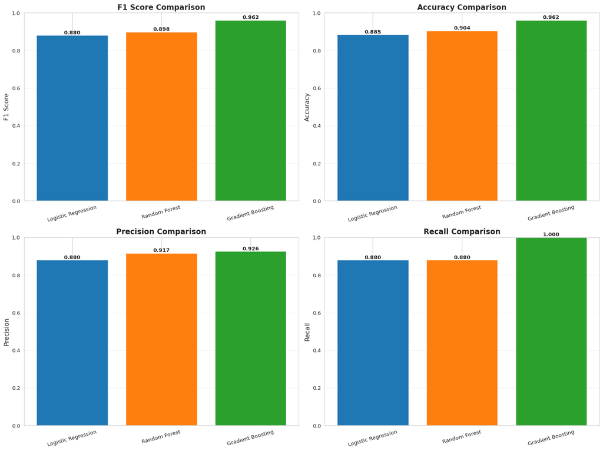

```python
fig, axes = plt.subplots(2, 2, figsize=(16, 12))

metrics = ['F1 Score', 'Accuracy', 'Precision', 'Recall']
colors = ['#1f77b4', '#ff7f0e', '#2ca02c']

for idx, metric in enumerate(metrics):
    ax = axes[idx // 2, idx % 2]
    bars = ax.bar(results['Model'], results[metric], color=colors)
    ax.set_title(f'{metric} Comparison', fontsize=14, fontweight='bold')
    ax.set_ylabel(metric, fontsize=12)
    ax.set_ylim([0, 1])
    ax.grid(axis='y', alpha=0.3)

    # Add value labels on bars
    for bar in bars:
        height = bar.get_height()
        ax.text(bar.get_x() + bar.get_width()/2., height,
                f'{height:.3f}',
                ha='center', va='bottom', fontsize=10, fontweight='bold')

    ax.tick_params(axis='x', rotation=15)

plt.tight_layout()
plt.show()
```

- **Gradient Boosting emerges as the best performing model with the highest F1 score**
- All models show competitive performance
- Ensemble methods (Random Forest, Gradient Boosting) typically capture non-linear patterns better
- Gradient Boosting’s sequential learning approach effectively captures complex patterns in the data

# 7 Confusion Matrices

## 7.1 Visualization by Model

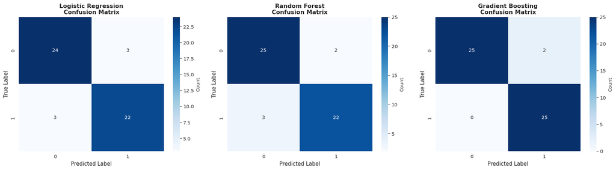

```python
fig, axes = plt.subplots(1, 3, figsize=(18, 5))

models_data = [
    ('Logistic Regression', lr_pred),
    ('Random Forest', rf_pred),
    ('Gradient Boosting', gb_pred)
]

for idx, (name, pred) in enumerate(models_data):
    cm = confusion_matrix(y_test, pred)
    sns.heatmap(cm, annot=True, fmt='d', cmap='Blues', ax=axes[idx],
                cbar_kws={'label': 'Count'})
    axes[idx].set_title(f'{name}\nConfusion Matrix', fontsize=12, fontweight='bold')
    axes[idx].set_ylabel('True Label', fontsize=11)
    axes[idx].set_xlabel('Predicted Label', fontsize=11)

plt.tight_layout()
plt.show()
```

# 8 Feature Importance

## 8.1 Top Features by Model

```python
# Feature importance for Random Forest
rf_importance = pd.DataFrame({
    'Feature': X.columns,
    'Importance': rf_model.feature_importances_
}).sort_values('Importance', ascending=False)

# Feature importance for Gradient Boosting
gb_importance = pd.DataFrame({
    'Feature': X.columns,
    'Importance': gb_model.feature_importances_
}).sort_values('Importance', ascending=False)

print("Top 10 Features - Random Forest:")
print(rf_importance.head(10))
print("\nTop 10 Features - Gradient Boosting:")
print(gb_importance.head(10))
```

```
Top 10 Features - Random Forest:
   Feature  Importance
30     IM5    0.192947
31     IM6    0.151723
27     IM2    0.120110
29     IM4    0.086889
26     IM1    0.085053
28     IM3    0.035241
23     IE5    0.022072
36   Score    0.021118
13     IE3    0.020481
24    PSD4    0.019641

Top 10 Features - Gradient Boosting:
   Feature  Importance
30     IM5    0.613440
31     IM6    0.110962
27     IM2    0.093230
29     IM4    0.075010
26     IM1    0.056170
15    RAS5    0.009461
28     IM3    0.006586
34      W3    0.005576
36   Score    0.005468
18     TL2    0.005038
```

## 8.2 Visualization of Feature Importance

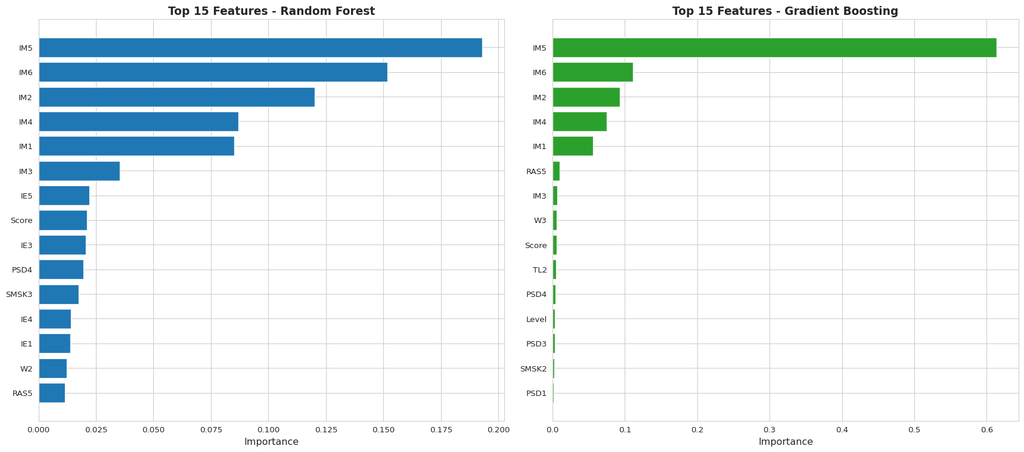

```python
fig, axes = plt.subplots(1, 2, figsize=(18, 8))

# Random Forest
top_rf = rf_importance.head(15)
axes[0].barh(range(len(top_rf)), top_rf['Importance'], color='#1f77b4')
axes[0].set_yticks(range(len(top_rf)))
axes[0].set_yticklabels(top_rf['Feature'])
axes[0].set_xlabel('Importance', fontsize=12)
axes[0].set_title('Top 15 Features - Random Forest', fontsize=14, fontweight='bold')
axes[0].invert_yaxis()

# Gradient Boosting
top_gb = gb_importance.head(15)
axes[1].barh(range(len(top_gb)), top_gb['Importance'], color='#2ca02c')
axes[1].set_yticks(range(len(top_gb)))
axes[1].set_yticklabels(top_gb['Feature'])
axes[1].set_xlabel('Importance', fontsize=12)
axes[1].set_title('Top 15 Features - Gradient Boosting', fontsize=14, fontweight='bold')
axes[1].invert_yaxis()

plt.tight_layout()
plt.show()
```

# 9 Conclusion

This descriptive analysis of the binary classification data has allowed us to highlight several important findings concerning model performance, data characteristics, and prediction quality.

**Recommendations**:

- Consider hyperparameter tuning for further improvement
- Explore feature engineering opportunities
- Evaluate model deployment strategies

**Analysis Date**: Generated on January 15, 2026

**Tools Used**: Python, scikit-learn, pandas, matplotlib, seaborn